# Evidence (briefly), part 2.

Andy Wills

## Before you start…

Before starting this worksheet, you should have completed all three previous worksheets of the Very Brief Guide to R. Once you have, you’ll have an R project that contains a script like this:

```r
# Exploring data (briefly)
# Load package
library(tidyverse)
# Load data into 'cpsdata'
cpsdata <- read_csv("cps2.csv")
# Display mean income
cpsdata %>% summarise(mean(income))
# Calculate mean hours per week
cpsdata %>% summarise(mean(hours, na.rm = TRUE))

# Group differences (briefly)
# Group by sex, display mean income
cpsdata %>% group_by(sex) %>% summarise(mean(income))
# Display density plot of income, by sex
cpsdata %>% ggplot(aes(income, colour = factor(sex))) + geom_density(aes(y = ..scaled..))
# Filter people with income < $150K into 'cpslow'
cpslow <- cpsdata %>% filter(income < 150000)
# Display density plot of incomes below $150K, by sex
cpslow %>% ggplot(aes(income, colour = factor(sex))) + geom_density(aes(y = ..scaled..))
# EXERCISE
# Group by 'native', display mean income below $150K
cpslow %>% group_by(native) %>% summarise(mean(income))
# Display density plot of incomes below $150K, by 'native'
cpslow %>% ggplot(aes(income, colour = factor(native))) + geom_density(aes(y = ..scaled..))

# Evidence (briefly), part 1
# Load BayesFactor package
library(BayesFactor, quietly = TRUE)
# Calculate Bayesian t-test for effect of 'sex', on 'income'
ttestBF(formula = income ~ sex, data = data.frame(cpsdata))
# Calculate traditional t-test for effect of 'sex' on 'income'
t.test(cpsdata$income ~ cpsdata$sex)
# Exercise
# Calculate Bayesian t-test for effect of 'native', on incomes below $150K
ttestBF(formula = income ~ native, data = data.frame(cpslow))
# Calculate traditional t-test for effect of 'native' on incomes below £150K
t.test(cpslow$income ~ cpslow$native)
```

## Contents

- Loading new data
- Scatter plots
- Measuring correlation
- Evidence for correlation
- Exercise

## Loading new data

Here’s what each of the column labels mean:

| Column | Description | Values |
| --- | --- | --- |
| grp | ID number of the group | a number |
| ingroup | Group’s mean rating of ingroup closeness | 1 (low) - 10 (high) |
| outgroup | Group’s mean rating of outgroup distance | 1 (low) - 10 (high) |
| dominance | Group’s mean rating of the dominance of their group leader | 1 (low) - 10 (high) |

This is a small dataset comprising 25 groups.

## Scatterplots

One question we can ask about these data concerns the relationship between ingroup closeness and outgroup distance.

For example, does high ingroup closeness tend to be associated with high outgroup distance – perhaps feeling close to your ingroup is associated with feeling distant from your outgroup?

Or perhaps high ingroup closeness is associated with low outgroup distance — feeling close to your own group also makes you feel close to other groups? Or, a third option, perhaps the two things are unrelated — whether you have high or low ingroup closeness does not predict your outgroup distance.

One way to look at this question is to produce a *scatterplot*. On a scatterplot, each point represents one group. That point’s position on the x-axis represents their ingroup closeness, and that point’s position on the y-axis represents their outgroup distance.

The command to produce a scatterplot in R is much like the command for a density plot. It is:

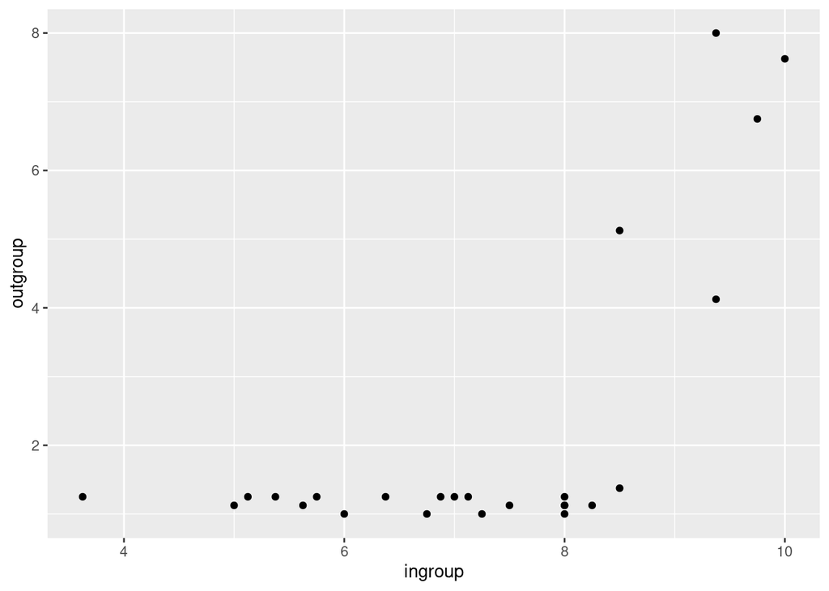

```r
# Display scatterplot of 'ingroup' versus 'outgroup'
gdata %>% ggplot(aes(x = ingroup, y = outgroup)) + geom_point()
```

### Explanation of command

The command takes the data from the `gdata` dataframe, and *pipes* it (`%>%`) to `ggplot` to produce a graph. The rest of the command tells `ggplot` what type of graph we want:

`geom_point()` - We want a scatterplot

`aes(x = ingroup, y = outgroup)` - We want the variable `ingroup` on the x-axis, and the variable `outgroup` on th y-axis.

### Discussion of output

So it seems that, in this example dataset, ingroup closeness and outgroup distance are related. We call this type of relationship a *correlation*.

## Measuring correlation

Sometimes, it’s useful to have a single number that summarises how well two variables are correlated. We can calculate this number, called a *correlation co-efficient*, using the `cor` command in R:

```r
# Display correlation co-efficient for 'ingroup' versus 'outgroup'
cor(gdata$ingroup, gdata$outgroup)
```

```
[1] 0.6641777
```

### Explanation of command

Here’s what each part of the command means:

`cor()` - The command to calculate a correlation co-efficient.

`gdata$ingroup` - One variable is in the `ingroup` column of the `gdata` data frame.

`,` - this comma needs to be here so R knows where one variable ends and the other begins.

`gdata$outgroup` - The other variable is in the `outgroup` column of the `gdata` data frame.

### Explanation of output

In the above example, the correlation co-efficient was about 0.66. By tradition, we use a lower case *r* to represent a correlation co-efficient, so here *r = 0.66*. In order to make sense of this number, you need to know that the biggest *r* can ever be is 1, and the smallest it can ever be is -1.

**Where r = 1**: A correlation of 1 means a perfect linear relationship. In other words, there is a straight line you can draw that goes exactly through the centre of each dot on your scatterplot. The line can be shallow, or steep. Here are some examples:

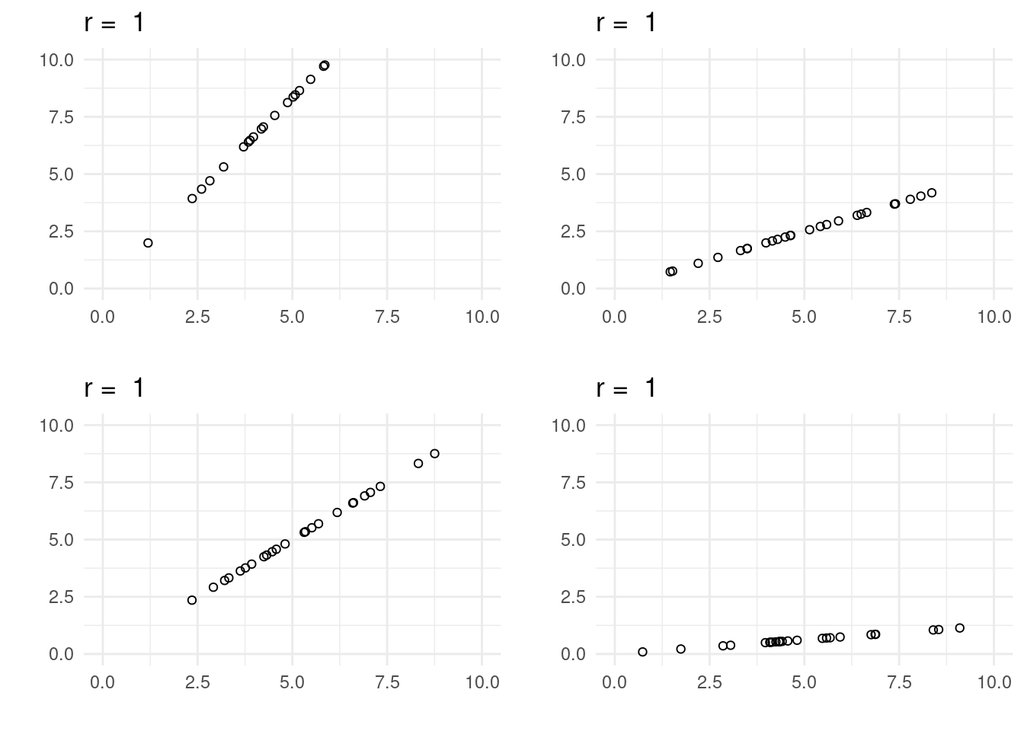

**Where r = 0**: A correlation of zero means there is no relationship between the two variables. Here are some examples:

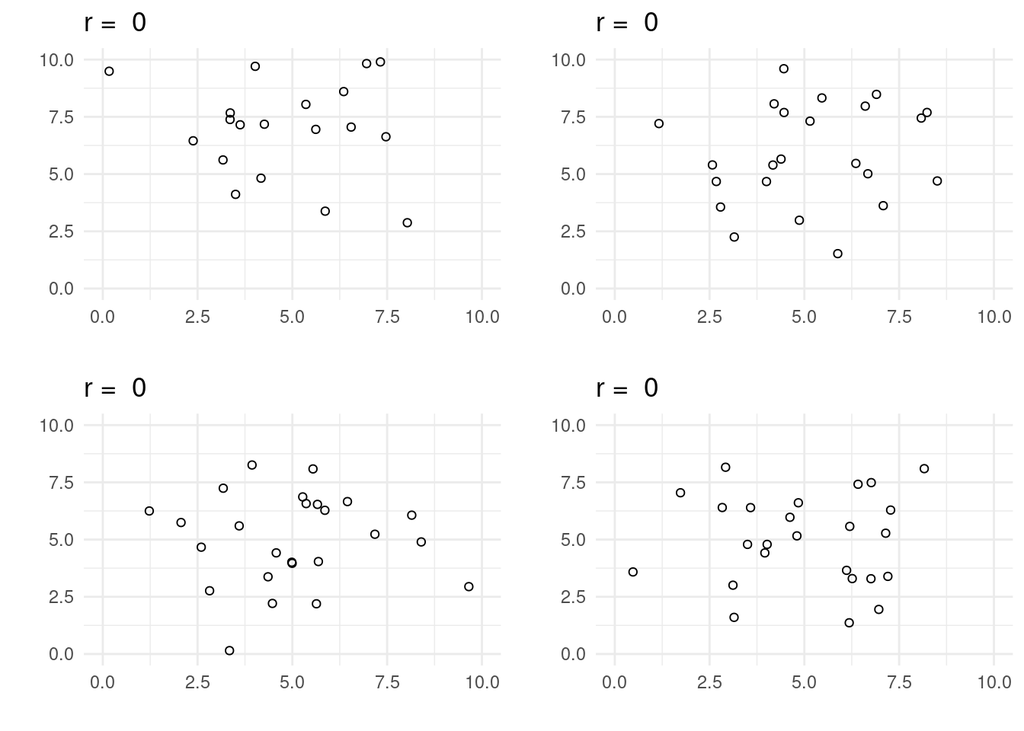

**Where r is between 0 and 1:** As the correlation co-efficient gets further from zero, the relationship between the two variables becomes more like a straight line. Here are some more examples:

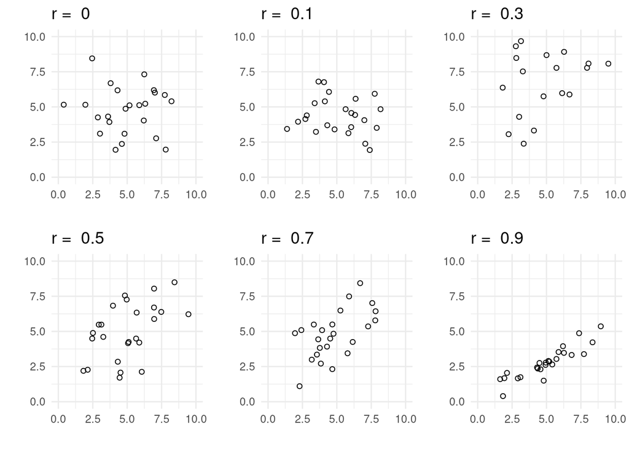

**Where r is less than 0:** A negative correlation co-efficient just means that, as one variable gets larger, the other gets smaller:

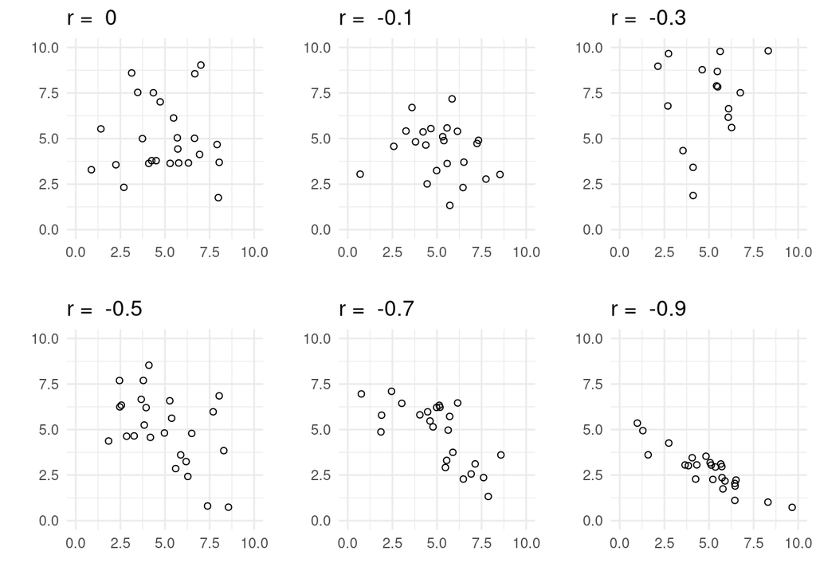

## Evidence for correlation

So far, we’ve produced a scatterplot of *ingroup closeness* versus *outgroup distance*, and we’ve calculated a correlation co-efficient for that relationship ( *r=0.66* in the example above). But is the relationship between these two variables real, or a fluke? Much like the Bayesian t-test we calculated in the previous worksheet, we can calculate a Bayes Factor for the relationship between two variables. This uses the same *BayesFactor* package, which we already loaded in the last worksheet.

To calculate a Bayes Factor for the correlation, we use the `correlationBF` command, which has a similar format to the `cor` command above:

```r
# Calculate Bayes Factor for correlation between 'ingroup' and 'outgroup'
correlationBF(gdata$ingroup, gdata$outgroup)
```

```
Bayes factor analysis
--------------
[1] Alt., r=0.333 : 89.70525 ±0%

Against denominator:
  Null, rho = 0
---
Bayes factor type: BFcorrelation, Jeffreys-beta*
```

The Bayes Factor is reported on the third line, towards the right. In this example, our Bayes Factor is about 89.7. This means it’s about ninety times as likely there is a relationship between these two variables as there isn’t. This is larger than the conventional threshold of 3, so psychologists will generally believe you when you claim that there is a relationship between ingroup closeness and outgroup distance. If the Bayes Factor had been less than 0.33, this would have been evidence that there was no relationship.

### Traditional analysis

As we covered in the Evidence worksheet, historically psychologists have typically reported *p values*, despite the fact that *p values* are widely misinterpreted. If you want to calculate a *p value* for a correlation co-efficient, you can use the following command:

```r
# Calculate traditional test for correlation between 'ingroup' and 'outgroup'
cor.test(gdata$ingroup, gdata$outgroup)
```

[output not shown]

## Exercise

Start by adding the following to your script:

```
# EXERCISE
```

In this exercise, you’ll apply what you’ve learned to the relationship between *ingroup closeness*, and *group-leader dominance*. Do each of the following analyses, adding the appropriate comments and commands to your script:

1. Make a scatterplot with *ingroup* closeness on the x-axis, and group-leader *dominance* on the y-axis.
2. Calculate the correlation co-efficient for *ingroup* versus *dominance*.
3. Calculate the Bayes Factor for this correlation.

### Expected output

If you’ve done it right, these are the answers you’ll get:

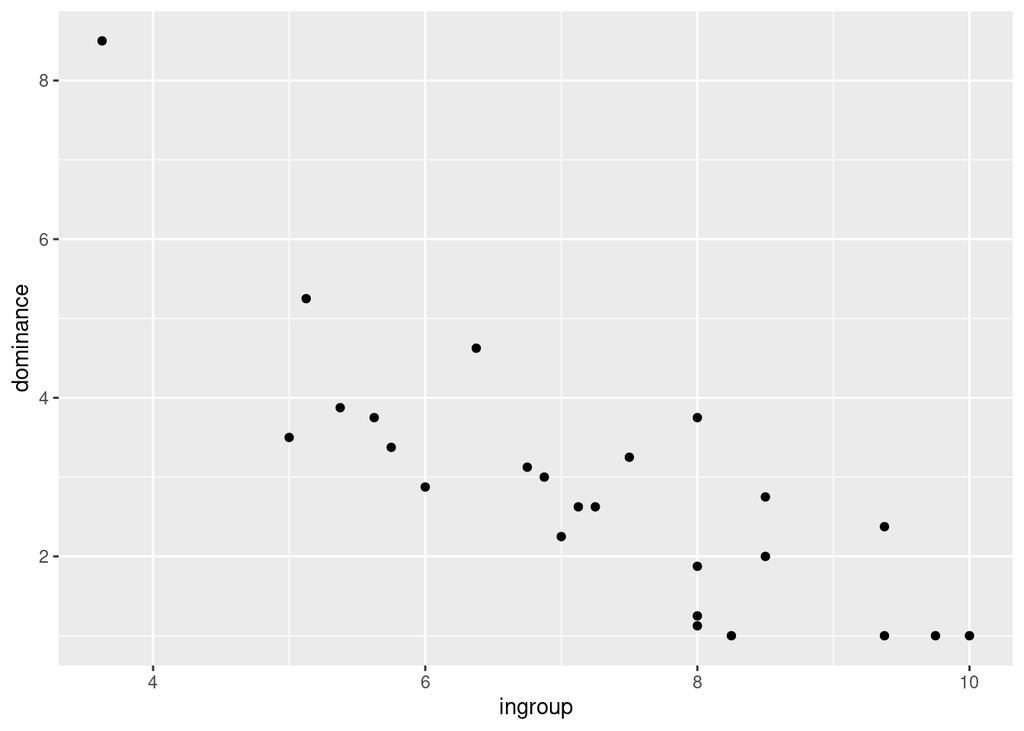

```
[1] -0.8196067
```

```
Bayes factor analysis
--------------
[1] Alt., r=0.333 : 10578.51 ±0%

Against denominator:
  Null, rho = 0
---
Bayes factor type: BFcorrelation, Jeffreys-beta*
```

## The End!

If you’re able to complete the above exercise on your own, you’re all set! If not, ask for help in class, and/or work through the Absolute Beginners’ Guide to R

This material is distributed under a [Creative Commons](https://creativecommons.org/) licence. CC-BY-SA 4.0.